# PROJECT

# Analisis Sisaan

Model terbaik hasil identifikasi kemudian dicek asumsi sisaannya. Sisaan model ARIMA harus memenuhi asumsi normalitas, kebebasan sisaan, dan kehomogenan ragam. Diagnostik model dilakukan secara eksplorasi dan uji formal.

## Eksplorasi Sisaan

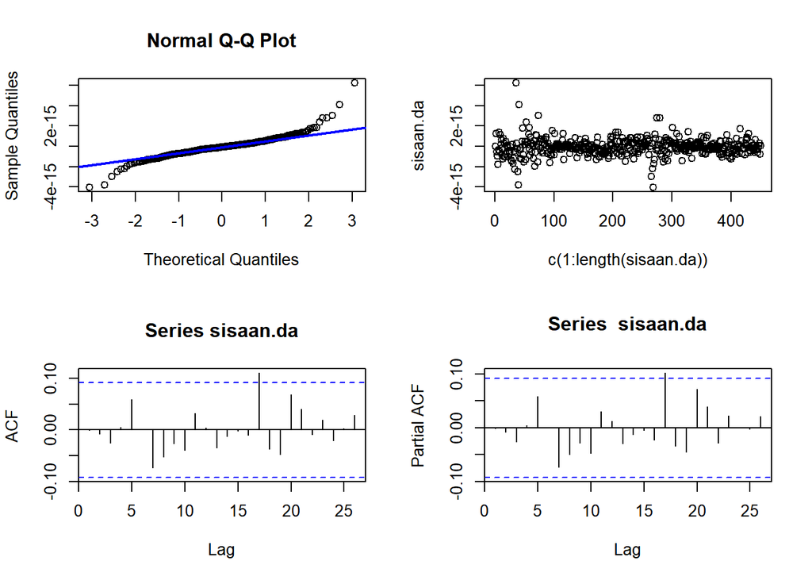

```r
#Eksplorasi
sisaan.da <- model2.da$residuals
par(mfrow=c(2,2))
qqnorm(sisaan.da)
qqline(sisaan.da, col = "blue", lwd = 2)
plot(c(1:length(sisaan.da)),sisaan.da)
acf(sisaan.da)
pacf(sisaan.da)
```

```r
par(mfrow = c(1,1))
```

## Sisaan Menyebar Normal

```r
ks.test(sisaan.da,"pnorm")
```

```
##
##  Asymptotic one-sample Kolmogorov-Smirnov test
##
## data:  sisaan.da
## D = 0.5, p-value < 2.2e-16
## alternative hypothesis: two-sided
```

Selain dengan eksplorasi, asumsi tersebut dapat diuji menggunakan uji formal. Pada tahapan ini uji formal yang digunakan untuk normalitas adalah uji Kolmogorov-Smirnov (KS). Hipotesis pada uji KS adalah sebagai berikut.

$H_0$ : Sisaan menyebar normal

$H_1$ : Sisaan tidak menyebar normal

Berdasarkan uji KS tersebut, didapat *p-value* sebesar $2.2\times10^{-16}$ yang kurang dari taraf nyata 5% sehingga tolak $H_0$ dan menandakan bahwa sisaan tidak menyebar normal. Hal ini sesuai dengan hasil eksplorasi menggunakan plot kuantil-kuantil normal.

## Sisaan Saling Bebas

```r
Box.test(sisaan.da, type = "Ljung")
```

```
##
##  Box-Ljung test
##
## data:  sisaan.da
## X-squared = 0.00068489, df = 1, p-value = 0.9791
```

Selanjutnya akan dilakukan uji formal untuk kebebasan sisaan menggunakan uji Ljung-Box. Hipotesis yang digunakan adalah sebagai berikut.

$H_0$ : Sisaan saling bebas

$H_1$ : Sisaan tidak saling bebas

## Sisaan Homogen

```r
Box.test((sisaan.da)^2, type = "Ljung")
```

```
##
##  Box-Ljung test
##
## data:  (sisaan.da)^2
## X-squared = 8.3657, df = 1, p-value = 0.003824
```

Hipotesis yang digunakan untuk uji kehomogenan ragam adalah sebagai berikut.

$H_0$ : Ragam sisaan homogen

$H_1$ : Ragam sisaan tidak homogen

Berdasarkan uji Ljung-Box terhadap sisaan kuadrat tersebut, didapat *p-value* sebesar $0.003824$ yang kurang dari taraf nyata 5% sehingga tolak $H_0$ dan menandakan bahwa ragam sisaan tidak homogen.

## Nilai Tengah Sisaan = 0

```r
t.test(sisaan.da, mu = 0, conf.level = 0.95)
```

```
##
##  One Sample t-test
##
## data:  sisaan.da
## t = -1.7685, df = 449, p-value = 0.07766
## alternative hypothesis: true mean is not equal to 0
## 95 percent confidence interval:
##  -1.500124e-16  7.905051e-18
## sample estimates:
##     mean of x
## -7.105368e-17
```

Terakhir, dengan uji-t, akan dicek apakah nilai tengah sisaan sama dengan nol. Hipotesis yang diujikan sebagai berikut.

$H_0$ : nilai tengah sisaan sama dengan 0

$H_1$ : nilai tengah sisaan tidak sama dengan 0

## Uji Efek ARCH

```r
bydArchTest1 <- ArchTest(sisaan.da, lags=1, demean=TRUE)
bydArchTest1
```

```
##
##  ARCH LM-test; Null hypothesis: no ARCH effects
##
## data:  sisaan.da
## Chi-squared = 6.8816, df = 1, p-value = 0.008709
```

```r
bydArchTest2 <- ArchTest(sisaan.da, lags=2, demean=TRUE)
bydArchTest2
```

```
##
##  ARCH LM-test; Null hypothesis: no ARCH effects
##
## data:  sisaan.da
## Chi-squared = 9.9434, df = 2, p-value = 0.006931
```

```r
bydArchTest5 <- ArchTest(sisaan.da, lags=5, demean=TRUE)
bydArchTest5
```

```
##
##  ARCH LM-test; Null hypothesis: no ARCH effects
##
## data:  sisaan.da
## Chi-squared = 58.778, df = 5, p-value = 2.173e-11
```

```r
bydArchTest10 <- ArchTest(sisaan.da, lags=10, demean=TRUE)
bydArchTest10
```

```
##
##  ARCH LM-test; Null hypothesis: no ARCH effects
##
## data:  sisaan.da
## Chi-squared = 67.763, df = 10, p-value = 1.196e-10
```

```r
bydArchTest20 <- ArchTest(sisaan.da, lags=20, demean=TRUE)
bydArchTest20
```

```
##
##  ARCH LM-test; Null hypothesis: no ARCH effects
##
## data:  sisaan.da
## Chi-squared = 74.685, df = 20, p-value = 3.075e-08
```

karena dari semua percobaan dengan lags yang berbeda beda menghasilkan p-value yang lebih kecil dari 0.05 maka tolak H0, maka dapat langsung menggunakan GARCH

## GARCH(1,1)

```r
# Mean data.diff
mean <- mean(data.diff)

# Simp.baku data.diff
sb <- sd(data.diff)

# Penskalaan data untuk mengurangi perbedaan skala antar variabel
data.diff <- scale(data.diff)

# Pastikan data tidak mengandung NA
data.diff <- na.omit(data.diff)

# Spesifikasi model GARCH(1,1) sederhana
garch11.spec <- ugarchspec(
  variance.model = list(model = "sGARCH", garchOrder = c(1, 1)),
  mean.model = list(armaOrder = c(3, 3), include.mean = FALSE))

# Fit model dengan solver hybrid
garch11.fit <- ugarchfit(
  spec = garch11.spec,
  data = data.diff,
  solver="hybrid"
)


# Tampilkan hasil
garch11.fit
```

```
##
## *---------------------------------*
## *          GARCH Model Fit        *
## *---------------------------------*
##
## Conditional Variance Dynamics
## -----------------------------------
## GARCH Model  : sGARCH(1,1)
## Mean Model   : ARFIMA(3,0,3)
## Distribution : norm
##
## Optimal Parameters
## ------------------------------------
##         Estimate  Std. Error    t value Pr(>|t|)
## ar1    -0.717644    0.035272   -20.3459 0.000000
## ar2     0.793975    0.029167    27.2213 0.000000
## ar3     0.680143    0.035190    19.3275 0.000000
## ma1     0.617117    0.001426   432.7360 0.000000
## ma2    -0.928648    0.000753 -1232.5949 0.000000
## ma3    -0.684195    0.001366  -500.7344 0.000000
## omega   0.040826    0.015549     2.6255 0.008651
## alpha1  0.175752    0.041887     4.1959 0.000027
## beta1   0.781153    0.045130    17.3089 0.000000
##
## Robust Standard Errors:
##         Estimate  Std. Error    t value Pr(>|t|)
## ar1    -0.717644    0.041699   -17.2100 0.000000
## ar2     0.793975    0.056702    14.0025 0.000000
## ar3     0.680143    0.036470    18.6494 0.000000
## ma1     0.617117    0.000257  2403.0326 0.000000
## ma2    -0.928648    0.000652 -1424.6518 0.000000
## ma3    -0.684195    0.000273 -2503.6757 0.000000
## omega   0.040826    0.015039     2.7148 0.006632
## alpha1  0.175752    0.065529     2.6821 0.007317
## beta1   0.781153    0.048733    16.0291 0.000000
##
## LogLikelihood : -545.5333
##
## Information Criteria
## ------------------------------------
```

[output cut: 52 more lines]

```
## Negative Sign Bias  0.7852 0.4328
## Positive Sign Bias  1.1115 0.2670
## Joint Effect        3.8793 0.2748
##
##
## Adjusted Pearson Goodness-of-Fit Test:
## ------------------------------------
##   group statistic p-value(g-1)
## 1    20     42.54     0.001499
## 2    30     46.97     0.018753
## 3    40     58.88     0.021372
## 4    50     79.62     0.003698
##
##
## Elapsed time : 0.2117538
```

# Eksplorasi Sisaan

```r
#Eksplorasi
sisaan.da2 <- garch11.fit@fit$residuals
sisaan.da2
```

[output not shown]

[output cut: 75 more lines]

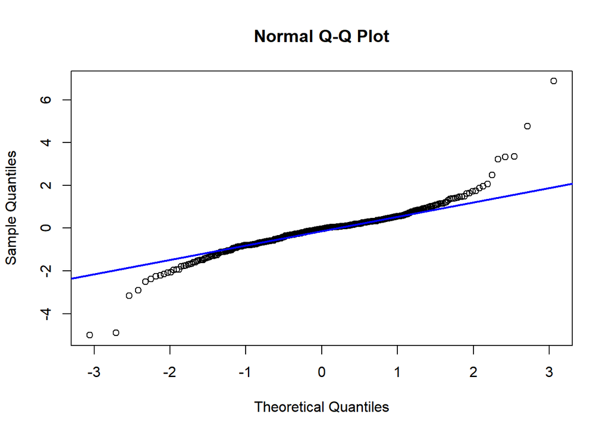

```r
par(mfrow=c(1,1)) # Ubah sesuai kebutuhan
qqnorm(sisaan.da2)
qqline(sisaan.da2, col = "blue", lwd = 2)
```

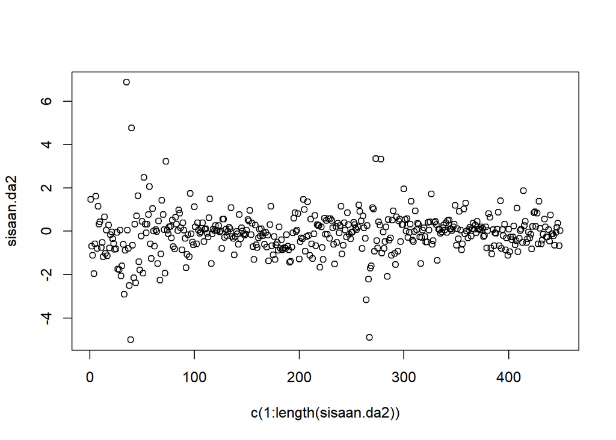

```r
plot(c(1:length(sisaan.da2)),sisaan.da2)
```

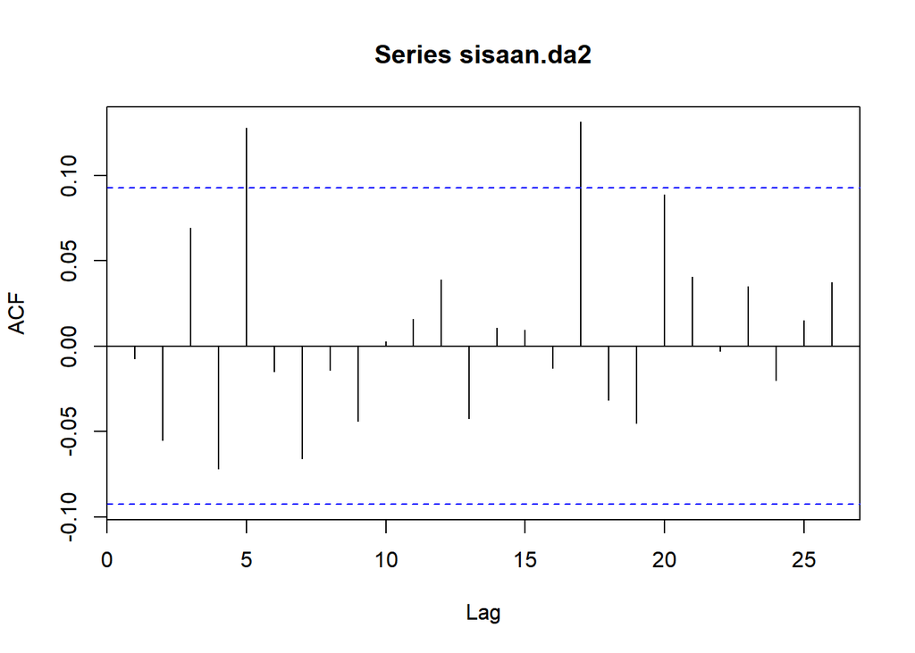

```r
acf(sisaan.da2)
```

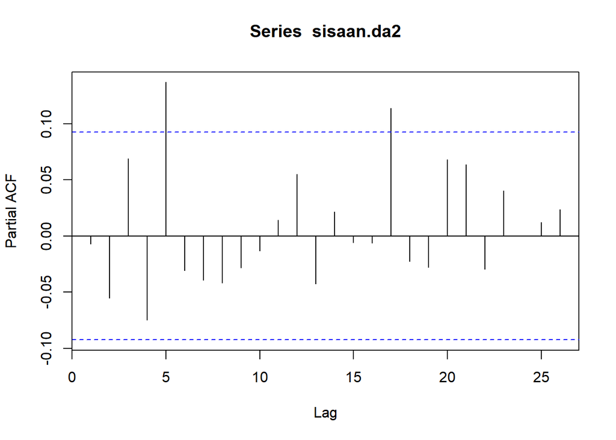

```r
pacf(sisaan.da2)
```